# Analyzing COVID-19 in the US and the Rest of the World

by Hira Mahmood

## Introduction

The global COVID-19 pandemic has had, and continues to have, devastating effects across the the US and the rest of the world. However, countries are being effected on vastly different scales. Are there trends across these countries that help us predict COVID-19 severity? How about just within the US? This tutorial is going to walk through an analysis of COVID-19 US and global trends.

## Data Collection

### Setting Up

To start, we need to install the necessary Python packages.

```python
import pandas as pd
import matplotlib.pyplot as plt
import numpy as np
import sklearn
import seaborn as sns
from scipy.stats import pearsonr
from scipy.stats import spearmanr
```

### Loading Data

We will be using the Data on COVID-19 complete dataset, maintained by *Our World in Data*. The dataset is compiled from various credible sources, including Johns Hopkins University and the European Centre for Disease Prevention and Control. Full information on the data, as well as the data itself, can be found at https://github.com/owid/covid-19-data/tree/master/public/data.

The data we will be using was retrieved on 5/11/2021, and contains data through 5/10/2021.

It's important to note that the data is subject to reporting from countries, and there is evidence that indicates some countries could be under-reporting COVID-19 cases or deaths: https://www.cfr.org/in-brief/how-much-are-countries-underreporting-covid-19-cases-and-deaths

```python
data = pd.read_csv("owid-covid-data.csv")
data.head()
```

|  | iso_code | continent | location | date | total_cases | new_cases | new_cases_smoothed | total_deaths | new_deaths | new_deaths_smoothed | ... | gdp_per_capita | extreme_poverty | cardiovasc_death_rate | diabetes_prevalence | female_smokers | male_smokers | handwashing_facilities | hospital_beds_per_thousand | life_expectancy | human_development_index |
| --- | --- | --- | --- | --- | --- | --- | --- | --- | --- | --- | --- | --- | --- | --- | --- | --- | --- | --- | --- | --- | --- |
| 0 | AFG | Asia | Afghanistan | 2020-02-24 | 1.0 | 1.0 | NaN | NaN | NaN | NaN | ... | 1803.987 | NaN | 597.029 | 9.59 | NaN | NaN | 37.746 | 0.5 | 64.83 | 0.511 |
| 1 | AFG | Asia | Afghanistan | 2020-02-25 | 1.0 | 0.0 | NaN | NaN | NaN | NaN | ... | 1803.987 | NaN | 597.029 | 9.59 | NaN | NaN | 37.746 | 0.5 | 64.83 | 0.511 |
| 2 | AFG | Asia | Afghanistan | 2020-02-26 | 1.0 | 0.0 | NaN | NaN | NaN | NaN | ... | 1803.987 | NaN | 597.029 | 9.59 | NaN | NaN | 37.746 | 0.5 | 64.83 | 0.511 |
| 3 | AFG | Asia | Afghanistan | 2020-02-27 | 1.0 | 0.0 | NaN | NaN | NaN | NaN | ... | 1803.987 | NaN | 597.029 | 9.59 | NaN | NaN | 37.746 | 0.5 | 64.83 | 0.511 |
| 4 | AFG | Asia | Afghanistan | 2020-02-28 | 1.0 | 0.0 | NaN | NaN | NaN | NaN | ... | 1803.987 | NaN | 597.029 | 9.59 | NaN | NaN | 37.746 | 0.5 | 64.83 | 0.511 |

5 rows × 59 columns

### Tidying the Data

The data has several NaN values through March 2020, presumably because this was when cases had just started to rise globally. To make things easier, we will only be looking at data from April 2020 onwards. We're choosing to do this because the remaining data is still large enough for us to analyze and find possible trends.

```python
data = data[(data['date'] >= '2020-04-01')]
data.reset_index(inplace=True)
data = data.drop(['index'], axis=1)
```

There are some countries that are included in the dataset, but have no COVID-19 data (all column values are NaN). We will be dropping these.

The data contains many fields (59 columns!) but we are only interested in a smaller subset of them. For each country, along with data on covid, we will be looking at population, population density, GDP per capita, diabetes prevalence, life expectency, hospital beds per thousand, human development index, stringency index, and percent of population that is 65 and older. We will adjust the dataframe to only show these fields.

```python
data = data[['iso_code','continent','location','date','total_cases','total_deaths','total_cases_per_million',
             'total_deaths_per_million','new_cases', 'new_cases_per_million','new_deaths','new_deaths_per_million', 'new_vaccinations',
             'new_vaccinations_smoothed','new_vaccinations_smoothed_per_million','stringency_index', 'people_vaccinated_per_hundred',
             'population','population_density','aged_65_older','gdp_per_capita','diabetes_prevalence', 'new_cases_smoothed_per_million',
             'new_deaths_smoothed_per_million', 'hospital_beds_per_thousand','life_expectancy','human_development_index']]
```

There are still NaN values values for new_vaccinations_smoothed and new_vaccinations_smoothed_per_million. Upon inspection we can see that these NaN values exist for the dates when there was no vaccine available, or readily available. So we will be replacing these NaN values for those columns with zeros. Here is the final cleaned-up dataframe.

```python
data['new_vaccinations_smoothed'] = data['new_vaccinations_smoothed'].replace(np.nan, 0)
data['new_vaccinations_smoothed_per_million'] = data['new_vaccinations_smoothed_per_million'].replace(np.nan, 0)

#we'll also make some of the column names shorter
data.rename(columns = {'new_vaccinations_smoothed_per_million':'new_vacc_pm', 'total_cases_per_million':'total_cases_pm',
                       'total_deaths_per_million':'total_deaths_pm', 'new_cases_per_million': 'new_cases_pm',
                       'new_deaths_per_million':'new_deaths_pm','human_development_index':'hdi',
                       'population_density':'pop_density','hospital_beds_per_thousand':'hospital_beds_pt',
                       'diabetes_prevalence':'diabetes'}, inplace = True)
data.head()
```

|  | iso_code | continent | location | date | total_cases | total_deaths | total_cases_pm | total_deaths_pm | new_cases | new_cases_pm | ... | population | pop_density | aged_65_older | gdp_per_capita | diabetes | new_cases_smoothed_per_million | new_deaths_smoothed_per_million | hospital_beds_pt | life_expectancy | hdi |
| --- | --- | --- | --- | --- | --- | --- | --- | --- | --- | --- | --- | --- | --- | --- | --- | --- | --- | --- | --- | --- | --- |
| 0 | AFG | Asia | Afghanistan | 2020-04-01 | 197.0 | 4.0 | 5.061 | 0.103 | 22.0 | 0.565 | ... | 38928341.0 | 54.422 | 2.581 | 1803.987 | 9.59 | 0.444 | 0.007 | 0.5 | 64.83 | 0.511 |
| 1 | AFG | Asia | Afghanistan | 2020-04-02 | 240.0 | 4.0 | 6.165 | 0.103 | 43.0 | 1.105 | ... | 38928341.0 | 54.422 | 2.581 | 1803.987 | 9.59 | 0.587 | 0.004 | 0.5 | 64.83 | 0.511 |
| 2 | AFG | Asia | Afghanistan | 2020-04-03 | 275.0 | 8.0 | 7.064 | 0.206 | 35.0 | 0.899 | ... | 38928341.0 | 54.422 | 2.581 | 1803.987 | 9.59 | 0.675 | 0.018 | 0.5 | 64.83 | 0.511 |
| 3 | AFG | Asia | Afghanistan | 2020-04-04 | 300.0 | 10.0 | 7.706 | 0.257 | 25.0 | 0.642 | ... | 38928341.0 | 54.422 | 2.581 | 1803.987 | 9.59 | 0.708 | 0.022 | 0.5 | 64.83 | 0.511 |
| 4 | AFG | Asia | Afghanistan | 2020-04-05 | 338.0 | 12.0 | 8.683 | 0.308 | 38.0 | 0.976 | ... | 38928341.0 | 54.422 | 2.581 | 1803.987 | 9.59 | 0.807 | 0.029 | 0.5 | 64.83 | 0.511 |

5 rows × 27 columns

## Data Visualization and Analysis

Now that we have our data, we are going to create some visualizations to get an idea of what we are looking at and spot any potential trends.

We'll start off by creating a bar graph of total deaths caused by COVID-19 (as of May 1st 2021) for each country. We're going to pay more attention to deaths than cases, becuase we want to analyze the severity of COVID-19's impact.

```python
#Dropping all rows with non-country locations so we can get a df of just the countries
index_names = data[data['location'] == 'Africa'].index
index_names = index_names.union((data[data['location'] == 'Asia'].index))
index_names = index_names.union((data[data['location'] == 'World'].index))
index_names = index_names.union((data[data['location'] == 'Europe'].index))
index_names = index_names.union((data[data['location'] == 'International'].index))
index_names = index_names.union((data[data['location'] == 'North America'].index))
index_names = index_names.union((data[data['location'] == 'Oceania'].index))
index_names = index_names.union((data[data['location'] == 'South America'].index))
index_names = index_names.union((data[data['location'] == 'European Union'].index))

countries_df = data.drop(index_names)
```

```python
#retrieving data only from 5/1/2021 and then sorting it in descending order by number of total cases
current = countries_df[(countries_df['date'] == '2021-05-01')]
current_sorted = current.sort_values(['total_deaths'], ascending=False)
```

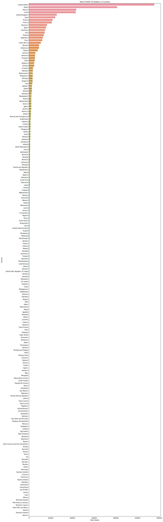

```python
#plotting
plt.figure(figsize=(16,64))
sns.barplot(x=current_sorted['total_deaths'],y=current_sorted['location'])
plt.xlabel("Total Deaths")
plt.ylabel("Country")
plt.title("Total COVID-19 Deaths vs Country")
plt.show()
```

Smaller countries seem to have low numbers of raw total deaths, but now let's look at total deaths per million people instead of just total deaths.

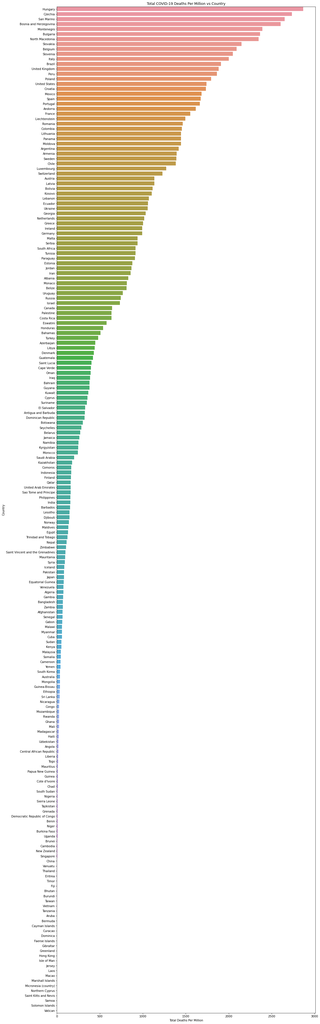

```python
current_sorted = current.sort_values(['total_deaths_pm'], ascending=False)
#plotting
plt.figure(figsize=(16,64))
sns.barplot(x=current_sorted['total_deaths_pm'],y=current_sorted['location'])
plt.xlabel("Total Deaths Per Million")
plt.ylabel("Country")
plt.title("Total COVID-19 Deaths Per Million vs Country")
plt.show()
```

Okay, now that we have an idea of what the data looks like, let's try to find some trends. One of the most obviuous one seems to be that countries with a higher stringency index would tend to have less deaths per million. The dataset defines stringency index as a composite measure of how strictly a country has responded to COVID-19, on a scale of 0-100.

We'll create a scatterplot that looks at deaths per million vs mean stringency index for each country.

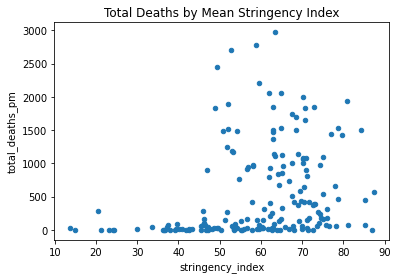

```python
#getting the mean stringency index for each country
countries_df_avg = countries_df.groupby('location')['stringency_index'].mean().reset_index()
countries_death = countries_df.groupby('location')['new_deaths_pm'].sum().reset_index()
countries_df_avg['total_deaths_pm'] = countries_death['new_deaths_pm']
#plotting
countries_df_avg.plot(x='stringency_index', y='total_deaths_pm', kind='scatter',
                 title='Total Deaths by Mean Stringency Index')
```

There doesn't appear to be a negative correlation between stringency index and total deaths per million. Interestingly, the majority of the countries with high deaths have stringency indices above 50. One explanation for this may be that countries are enforcing stricter covid regulations as their deaths get higher.

Let's instead look at daily stringency index vs daily deaths over time for one country: the U.S. This may give us an idea of whether or not regulations are working.

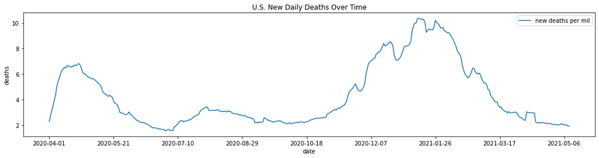

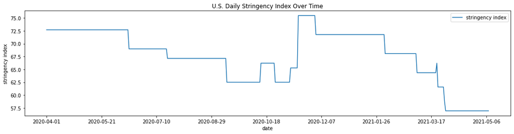

```python
indices = data[data['location'] != 'United States'].index
us_data = data.drop(indices)
plt.figure(figsize=(18,4))
plt.xticks(np.arange(0,405,50))
plt.plot(us_data['date'], us_data['new_deaths_smoothed_per_million'])
plt.legend(['new deaths per mil'])
plt.title('U.S. New Daily Deaths Over Time')
plt.xlabel('date')
plt.ylabel('deaths')
plt.show()

plt.figure(figsize=(18,4))
plt.xticks(np.arange(0,405,50))
plt.plot(us_data['date'], us_data['stringency_index'])
plt.legend(['stringency index'])
plt.title('U.S. Daily Stringency Index Over Time')
plt.xlabel('date')
plt.ylabel('stringency index')
plt.show()
```

Now let's test another possible trend by plotting deaths per million vs human development index (HDI).

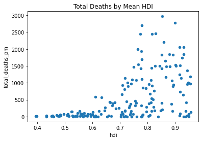

```python
countries_df_avg = countries_df.groupby('location')['hdi'].mean().reset_index()
countries_death = countries_df.groupby('location')['new_deaths_pm'].sum().reset_index()
countries_df_avg['total_deaths_pm'] = countries_death['new_deaths_pm']
countries_df_avg.plot(x='hdi', y='total_deaths_pm', kind='scatter',
                 title='Total Deaths by Mean HDI')
```

It appears that there is a relationship between mean HDI and total deaths per million. Countries with an HDI above 0.7 are reporting the most COVID-19 deaths per million. The key word here is reporting. One possible explanation for this data could be that countries with a lower HDI are more likely to under-report their COVID-19 deaths, as we had discussed earlier.

Now let's plot total deaths vs percent over 65 and see if we can find a relationship there.

[figure not shown]

```python
countries_df_avg = countries_df.groupby('location')['aged_65_older'].mean().reset_index()
countries_death = countries_df.groupby('location')['new_deaths_pm'].sum().reset_index()
countries_df_avg['total_deaths_pm'] = countries_death['new_deaths_pm']
countries_df_avg.plot(x='aged_65_older', y='total_deaths_pm', kind='scatter',
                 title='Total Deaths by Percent over 65')
```

It looks like there is a very weak general trend for COVID-19 deaths to be higher for countries where there are a higher percentage of people over 65.

Seems like finding strong trends is not easy! So now let's create a heatmap of the correlations between data fields in the global dataset. We can do this using seaborn. Numbers further from zero indicate a stronger correlation.

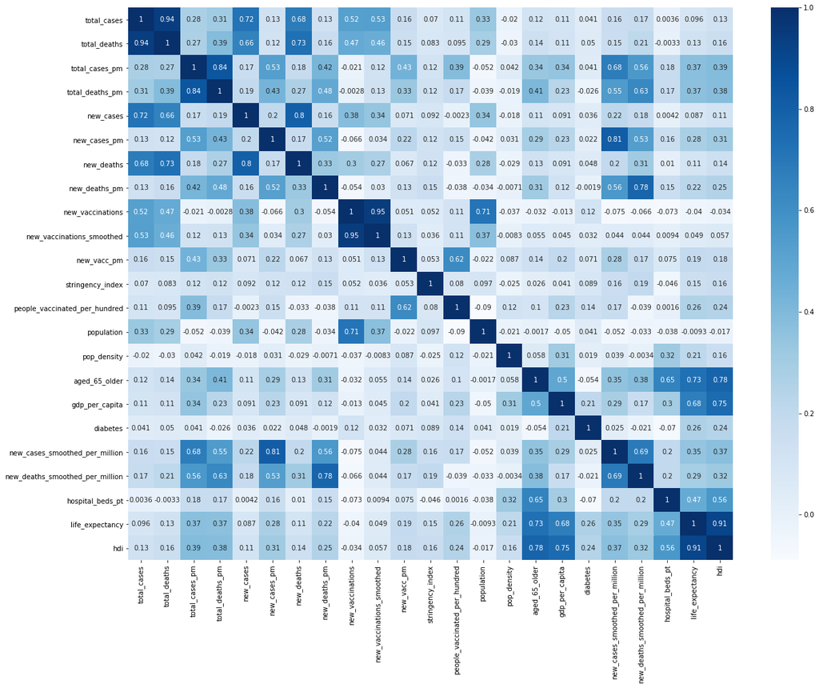

```python
plt.figure(figsize=(20,15))
sns.heatmap(countries_df.corr(), annot=True, cmap='Blues')
plt.show()
```

There don't seem to be any strong correlations between the COVID-19 statistics and general country statistics (such as life expectency, gdp per capita, etc). The correlations that do exist don't seem two connect the two types of data we have.

Let's now shift our focus to just one country. We may be able to find better trends within just one country, or a small group of countries, as the reporting remains consistent. Let's compare total vaccine doses administered to daily new cases per million in the US in 2021.

[figure not shown]

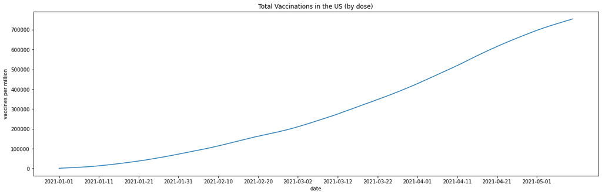

```python
#we're just going to look at this year, since vaccines weren't readily available last year
plt.figure(figsize=(20,6))
us_data_adj = us_data[(us_data['date'] >= '2021-01-01')]
us_data_adj['cumsum_vacc_pm'] = us_data_adj['new_vacc_pm'].cumsum()

#plotting new daily cases per million in the US
plt.xticks(np.arange(0,130,10))
plt.plot(us_data_adj['date'], us_data_adj['new_deaths_smoothed_per_million'])
plt.title('Daily New Cases Per Million in the US')
plt.xlabel('date')
plt.ylabel('cases per million')
plt.show()

#plotting total vaccinations in the US
plt.figure(figsize=(20,6))
plt.xticks(np.arange(0,130,10))
plt.plot(us_data_adj['date'], us_data_adj['cumsum_vacc_pm'])
plt.title('Total Vaccinations in the US (by dose)')
plt.xlabel('date')
plt.ylabel('vaccines per million')
plt.show()
```

Seems like there is some type of negative correlation between total vaccinations and daily cases. Let's test this with more countries! We will still need to keep it to select group, however, as we have seen that there are no strong correlations when looking at all countries. Unfortunately, this means we won't be able to make any global generalizations.

By doing some research, we can easily identify countries who have been distributing vaccines widely to their residents, similar to the US (source: https://www.nytimes.com/interactive/2021/world/covid-vaccinations-tracker.html). Thankfully, most of these countries have ample vaccination data in our dataset, so we will be looking at:

- the United States
- the United Kingdom
- Israel
- the UAE

We will plot total vaccinations per million vs new cases per million starting from February 1st 2021.

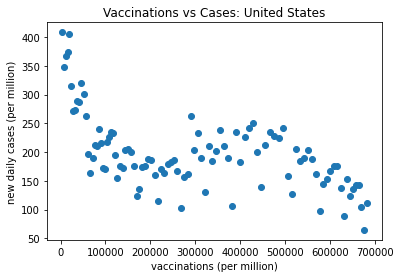

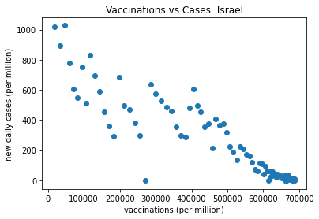

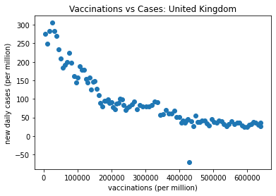

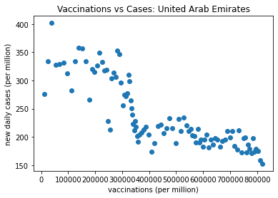

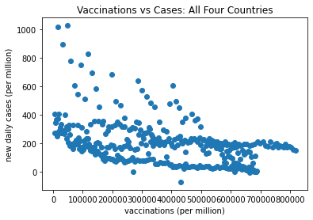

```python
countries = ['United States','Israel','United Kingdom','United Arab Emirates']
vaccinated = data[(data['date'] >= '2021-02-01')]
vaccinated['cumsum_vacc_pm'] = vaccinated.groupby('location')['new_vacc_pm'].cumsum()

#plotting each country
for x in countries:
    x_country = vaccinated[(vaccinated['location'] == x)]
    plt.scatter(x_country['cumsum_vacc_pm'], x_country['new_cases_pm'])
    plt.title('Vaccinations vs Cases: ' + x)
    plt.xlabel('vaccinations (per million)')
    plt.ylabel('new daily cases (per million)')
    plt.show()

#plotting all countries together
all_countries = vaccinated[(vaccinated['location'] == 'United States') | (vaccinated['location'] == 'Israel') |
                       (vaccinated['location'] == 'United Kingdom') | (vaccinated['location'] == 'United Arab Emirates')]
plt.scatter(all_countries['cumsum_vacc_pm'], all_countries['new_cases_pm'])
plt.title('Vaccinations vs Cases: All Four Countries')
plt.xlabel('vaccinations (per million)')
plt.ylabel('new daily cases (per million)')
plt.show()
```

For each of the four countries we have plotted, there seems to be a negative correlation between vaccinations and cases.

## Hypothesis Testing

Now that we've done a general analysis of the data and found a trend between vaccinations and positive cases, let's do some hypothesis testing to see how strong the correlation is between these two variables.

First let's briefly go over what hypothesis testing is. Hypothsis testing provides us a way to test our results to see if they are satistically meaningful. If the results are meaningful, we are able to reject our null hypothesis. In this case, our null hypothesis would be that there is no relationship between total number of vaccinations and new daily cases. We are going to perform tests to see if we can reject this hypothsis.

We'll first perform spearman correlation tests to determine the significance of a monotonic relationship between total vaccinations and new COVID cases in each country. It's important to remember that we are only looking at a sample of countries that have been distributing the vaccine widely (we chose the US, the UK, the UAE, and Israel). So any correlations we find in this data can't necessarily be generalized to the rest of the world.

I will be replacing the NaN values with zero, becuase upon observation of the dataset, it seems like days with zero cases are sometimes represented as NaN. The NaN values are also rare, so it shouldn't affect our results anyways, becuase we have a high volume of non-NaN values.

```python
#Spearman's Correlation test
for x in countries:
    x_country = vaccinated[(vaccinated['location'] == x)]
    data1 = x_country['cumsum_vacc_pm']
    data2 = x_country['new_cases_pm'].replace(np.nan, 0)
    r, p = spearmanr(data1, data2)
    print(x + ': r=%.3f, p=%.3f' % (r, p))
```

```
United States: r=-0.560, p=0.000
Israel: r=-0.918, p=0.000
United Kingdom: r=-0.952, p=0.000
United Arab Emirates: r=-0.883, p=0.000
```

Now let's perform pearson's correlation tests. This checks for a linear relationship, rather than just a monotonic one.

```python
#Pearson's Correlation test
for x in countries:
    x_country = vaccinated[(vaccinated['location'] == x)]
    data1 = x_country['cumsum_vacc_pm']
    data2 = x_country['new_cases_pm'].replace(np.nan, 0)
    r, p = pearsonr(data1, data2)
    print(x + ': r=%.3f, p=%.3f' % (r, p))
```

```
United States: r=-0.574, p=0.000
Israel: r=-0.919, p=0.000
United Kingdom: r=-0.859, p=0.000
United Arab Emirates: r=-0.841, p=0.000
```

While data like this (likely linear relationships with different r values), seems like it would be a good contender for a linear regression model with interaction terms for the countries, it would not be particularly useful in our case, given the context. The US's data is not strongly linear, and a linear regression for the other 3 countries (or even 4 countries with the US) would not be generalizable to other countries.

## Conclusion

It's difficult to predict how badly COVID-19 would effect a country based off its quantifiable statistics and traits. Contrary to what we might think, there doesn't seem to be a set factor across countries that is able to make such a prediction. If there is, it could be one of the many factors that our dataset does not carry, such as the spread of mutative strains. As we discussed earlier, evidence from other studies points to a lack of consistent reporting, which would certainly affect our ability to make predictions or effectively analyze trends as well.

We did find that new case rates are declining in countries with easy access to vaccines. But the rate at which cases decline varies by country, suggesting that external factors are also at play.

I hope that you've found this tutorial useful in getting started with the data science pipeline. I also hope that you've gained some insight into the unpredictability of COVID severity and the effectiveness of mass vaccinations.

## Sources

- the data from OWID: https://github.com/owid/covid-19-data/tree/master/public/data
- information on the reliability of COVID-19 data: https://www.cfr.org/in-brief/how-much-are-countries-underreporting-covid-19-cases-and-deaths
- additional info on hypothesis testing: https://www.statisticshowto.com/probability-and-statistics/hypothesis-testing/